# Customer Purchase Behavior Analysis using Descriptive Statistics

- Rijwan Shaikh

Git Hub Link: https://github.com/Rijwan94/DS_Pyhton_M2/blob/main/Applied_Statistics_Project_PBA_Rijwan_Shaikh.ipynb

## Problem Statement

🔍 **Problem Statement**:

Welcome to the Probability and Statistics project! 📊🔍 In this exciting journey, you'll get the chance to apply the concepts you've learned in probability theory and statistics to analyze a real-world dataset. This project is your opportunity to dive deep into the world of data analysis and gain practical experience with the tools and techniques you've been learning. 🚀

🎯 **Objective**:

Your mission is to analyze the provided dataset containing customer information and purchasing behavior to make informed decisions. Your goal is to identify patterns, trends, and correlations that will help your company optimize its marketing efforts and increase offer acceptance rates. 🎉

## About the Dataset

Here's the link to the [dataset](https://docs.google.com/spreadsheets/d/12ln9iTNcVNOMYi_AU-OczKpa_KIP8XyVbsjk81Na8Yk/edit?usp=sharing)

This data was gathered during last year's campaign. Data description is as follows;

1. Response (target) - 1 if customer accepted the offer in the last campaign, 0 otherwise
2. ID - Unique ID of each customer
3. Year_Birth - Age of the customer
4. Complain - 1 if the customer complained in the last 2 years
5. Dt_Customer - date of customer's enrollment with the company
6. Education - customer's level of education
7. Marital - customer's marital status
8. Kidhome - number of small children in customer's household
9. Teenhome - number of teenagers in customer's household
10. Income - customer's yearly household income
11. MntFishProducts - the amount spent on fish products in the last 2 years
12. MntMeatProducts - the amount spent on meat products in the last 2 years
13. MntFruits - the amount spent on fruits products in the last 2 years
14. MntSweetProducts - amount spent on sweet products in the last 2 years
15. MntWines - the amount spent on wine products in the last 2 years
16. MntGoldProds - the amount spent on gold products in the last 2 years
17. NumDealsPurchases - number of purchases made with discount
18. NumCatalogPurchases - number of purchases made using catalog (buying goods to be shipped through the mail)
19. NumStorePurchases - number of purchases made directly in stores
20. NumWebPurchases - number of purchases made through the company's website
21. NumWebVisitsMonth - number of visits to company's website in the last month
22. Recency - number of days since the last purchase

## Task 1 - Basic CleanUp

- **Clean and preprocess the dataset (handling missing values, data types, etc.).**
- **Analyze the distribution of customer demographics (age, education, marital status) using descriptive statistics and visualizations.**

**Deliverables**:

- **Cleaned and Preprocessed Dataset**:

  Provide a detailed report on the steps taken to handle missing values, including imputation methods used if applicable. Document the process of ensuring consistent data types for each variable, addressing any inconsistencies.
- **Summary of Basic Statistics**:

  Present calculated statistics such as mean, median, variance, and standard deviation for each relevant numerical variable. Include a concise table or summary showcasing these measures for easy reference.

# Load Dataset

### Required Libraries

```python
# 📦 Core Libraries
import pandas as pd
import numpy as np
from datetime import datetime

# 📊 Visualization
import matplotlib.pyplot as plt
import seaborn as sns
import plotly.express as px

# For Jupyter Notebooks to display plots inline
%matplotlib inline

# 📈 Machine Learning Tools
from sklearn.preprocessing import StandardScaler
from sklearn.cluster import KMeans
from sklearn.decomposition import PCA

# 📊 Statistics & Distributions
from scipy import stats
from scipy.stats import binom, norm, poisson, expon, skew, kurtosis, shapiro
from scipy.stats.mstats import winsorize

# 📋 Tabular Display
!pip install -q tabulate  # -q suppresses pip output
from tabulate import tabulate

# 📺 Display Tools
from IPython.display import display, HTML
from scipy.stats.mstats import winsorize
```

```python
pd.reset_option('display.max_rows')
```

Connect Drive

```python
#Connect drive
from google.colab import drive
drive.mount('/content/drive')
```

Load CSV File / Dataset

```python
#Load CSV File
PBA_df = pd.read_csv('/content/drive/MyDrive/Data Science/5. Applied Statistics/Mid Course/Superstore Marketing Data - Sheet1.csv', encoding='latin-1')
```

```python
#First look of Dataframe PBA_df
PBA_df
```

|  | Id | Year_Birth | Education | Marital_Status | Income | Kidhome | Teenhome | Dt_Customer | Recency | MntWines | ... | MntFishProducts | MntSweetProducts | MntGoldProds | NumDealsPurchases | NumWebPurchases | NumCatalogPurchases | NumStorePurchases | NumWebVisitsMonth | Response | Complain |
| --- | --- | --- | --- | --- | --- | --- | --- | --- | --- | --- | --- | --- | --- | --- | --- | --- | --- | --- | --- | --- | --- |
| 0 | 1826 | 1970 | Graduation | Divorced | 84835.0 | 0 | 0 | 6/16/2014 | 0 | 189 | ... | 111 | 189 | 218 | 1 | 4 | 4 | 6 | 1 | 1 | 0 |
| 1 | 1 | 1961 | Graduation | Single | 57091.0 | 0 | 0 | 6/15/2014 | 0 | 464 | ... | 7 | 0 | 37 | 1 | 7 | 3 | 7 | 5 | 1 | 0 |
| 2 | 10476 | 1958 | Graduation | Married | 67267.0 | 0 | 1 | 5/13/2014 | 0 | 134 | ... | 15 | 2 | 30 | 1 | 3 | 2 | 5 | 2 | 0 | 0 |
| 3 | 1386 | 1967 | Graduation | Together | 32474.0 | 1 | 1 | ######## | 0 | 10 | ... | 0 | 0 | 0 | 1 | 1 | 0 | 2 | 7 | 0 | 0 |
| 4 | 5371 | 1989 | Graduation | Single | 21474.0 | 1 | 0 | ######## | 0 | 6 | ... | 11 | 0 | 34 | 2 | 3 | 1 | 2 | 7 | 1 | 0 |
| ... | ... | ... | ... | ... | ... | ... | ... | ... | ... | ... | ... | ... | ... | ... | ... | ... | ... | ... | ... | ... | ... |
| 2235 | 10142 | 1976 | PhD | Divorced | 66476.0 | 0 | 1 | ######## | 99 | 372 | ... | 47 | 48 | 78 | 2 | 5 | 2 | 11 | 4 | 0 | 0 |
| 2236 | 5263 | 1977 | 2n Cycle | Married | 31056.0 | 1 | 0 | 1/22/2013 | 99 | 5 | ... | 3 | 8 | 16 | 1 | 1 | 0 | 3 | 8 | 0 | 0 |
| 2237 | 22 | 1976 | Graduation | Divorced | 46310.0 | 1 | 0 | ######## | 99 | 185 | ... | 15 | 5 | 14 | 2 | 6 | 1 | 5 | 8 | 0 | 0 |
| 2238 | 528 | 1978 | Graduation | Married | 65819.0 | 0 | 0 | 11/29/2012 | 99 | 267 | ... | 149 | 165 | 63 | 1 | 5 | 4 | 10 | 3 | 0 | 0 |
| 2239 | 4070 | 1969 | PhD | Married | 94871.0 | 0 | 2 | ######## | 99 | 169 | ... | 188 | 0 | 144 | 1 | 8 | 5 | 4 | 7 | 1 | 0 |

2240 rows × 22 columns

```python
# Get the number of rows and columns
rows, cols = PBA_df.shape
print(f"Number of rows: {rows}")
print(f"Number of columns: {cols}")
```

```
Number of rows: 2240
Number of columns: 22
```

```python
#Summary of PBA_df

print(PBA_df.info())
```

```
<class 'pandas.core.frame.DataFrame'>
RangeIndex: 2240 entries, 0 to 2239
Data columns (total 22 columns):
 #   Column               Non-Null Count  Dtype
---  ------               --------------  -----
 0   Id                   2240 non-null   int64
 1   Year_Birth           2240 non-null   int64
 2   Education            2240 non-null   object
 3   Marital_Status       2240 non-null   object
 4   Income               2216 non-null   float64
 5   Kidhome              2240 non-null   int64
 6   Teenhome             2240 non-null   int64
 7   Dt_Customer          2240 non-null   object
 8   Recency              2240 non-null   int64
 9   MntWines             2240 non-null   int64
 10  MntFruits            2240 non-null   int64
 11  MntMeatProducts      2240 non-null   int64
 12  MntFishProducts      2240 non-null   int64
 13  MntSweetProducts     2240 non-null   int64
 14  MntGoldProds         2240 non-null   int64
 15  NumDealsPurchases    2240 non-null   int64
 16  NumWebPurchases      2240 non-null   int64
 17  NumCatalogPurchases  2240 non-null   int64
 18  NumStorePurchases    2240 non-null   int64
 19  NumWebVisitsMonth    2240 non-null   int64
 20  Response             2240 non-null   int64
 21  Complain             2240 non-null   int64
dtypes: float64(1), int64(18), object(3)
memory usage: 385.1+ KB
None
```

```python
# Check for missing values
print(PBA_df.isnull().sum())
```

```
Id                      0
Year_Birth              0
Education               0
Marital_Status          0
Income                 24
Kidhome                 0
Teenhome                0
Dt_Customer             0
Recency                 0
MntWines                0
MntFruits               0
MntMeatProducts         0
MntFishProducts         0
MntSweetProducts        0
MntGoldProds            0
NumDealsPurchases       0
NumWebPurchases         0
NumCatalogPurchases     0
NumStorePurchases       0
NumWebVisitsMonth       0
Response                0
Complain                0
dtype: int64
```

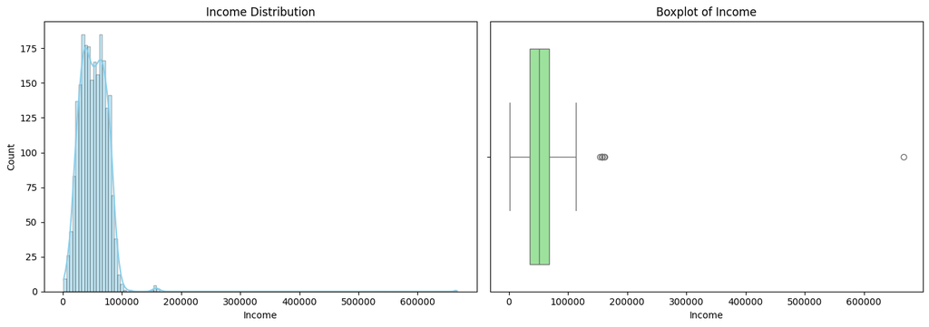

```
Mean Income: 52247.25
Median Income: 51381.5
Mode Income: 7500.0
Skewness: 6.76

✅ Based on the skewed distribution, MEDIAN is selected to impute missing values.

Missing values in 'Income' 24
```

```python
# Analyze and Impute Income Column
# 1. Visualize Income Distribution
plt.figure(figsize=(14, 5))

plt.subplot(1, 2, 1)
sns.histplot(PBA_df['Income'], kde=True, color='skyblue')
plt.title('Income Distribution')
plt.xlabel('Income')

plt.subplot(1, 2, 2)
sns.boxplot(x=PBA_df['Income'], color='lightgreen')
plt.title('Boxplot of Income')

plt.tight_layout()
plt.show()

# 2. Summary Statistics
income_mean = PBA_df['Income'].mean()
income_median = PBA_df['Income'].median()
income_mode = PBA_df['Income'].mode()[0]
income_skew = skew(PBA_df['Income'].dropna())

print("Mean Income:", round(income_mean, 2))
print("Median Income:", round(income_median, 2))
print("Mode Income:", income_mode)
print("Skewness:", round(income_skew, 2))

# 3. Based on analysis, MEDIAN is the best method
print("\n✅ Based on the skewed distribution, MEDIAN is selected to impute missing values.")

# 4. Confirm Imputation
print("\nMissing values in 'Income'", PBA_df['Income'].isnull().sum())
```

```python
PBA_df['Income'] = PBA_df['Income'].fillna(income_median)
```

```python
# 4. Confirm Imputation
print("\nMissing values in 'Income' after imputation:", PBA_df['Income'].isnull().sum())
```

```
Missing values in 'Income' after imputation: 0
```

```python
#Add new 'Age' Column to the df for better understanding
#Calculate today's date
today = datetime.today().year

# Function to calculate age
def calculate_age(year_birth):
    return today - year_birth

# Apply the function to create the 'Age' column
PBA_df['Age'] = PBA_df['Year_Birth'].apply(calculate_age)
```

```python
# Display 'Year_Birth' and added column 'Age'
print(PBA_df[['Year_Birth', 'Age']])
```

```
      Year_Birth  Age
0           1970   55
1           1961   64
2           1958   67
3           1967   58
4           1989   36
...          ...  ...
2235        1976   49
2236        1977   48
2237        1976   49
2238        1978   47
2239        1969   56

[2240 rows x 2 columns]
```

```python
PBA_df['TotalSpend'] = PBA_df[['MntFishProducts', 'MntMeatProducts', 'MntFruits', 'MntSweetProducts', 'MntWines', 'MntGoldProds']].sum(axis=1)
```

```python
#Final look on df
PBA_df
```

|  | Id | Year_Birth | Education | Marital_Status | Income | Kidhome | Teenhome | Dt_Customer | Recency | MntWines | ... | MntGoldProds | NumDealsPurchases | NumWebPurchases | NumCatalogPurchases | NumStorePurchases | NumWebVisitsMonth | Response | Complain | Age | TotalSpend |
| --- | --- | --- | --- | --- | --- | --- | --- | --- | --- | --- | --- | --- | --- | --- | --- | --- | --- | --- | --- | --- | --- |
| 0 | 1826 | 1970 | Graduation | Divorced | 84835.0 | 0 | 0 | 6/16/2014 | 0 | 189 | ... | 218 | 1 | 4 | 4 | 6 | 1 | 1 | 0 | 55 | 1190 |
| 1 | 1 | 1961 | Graduation | Single | 57091.0 | 0 | 0 | 6/15/2014 | 0 | 464 | ... | 37 | 1 | 7 | 3 | 7 | 5 | 1 | 0 | 64 | 577 |
| 2 | 10476 | 1958 | Graduation | Married | 67267.0 | 0 | 1 | 5/13/2014 | 0 | 134 | ... | 30 | 1 | 3 | 2 | 5 | 2 | 0 | 0 | 67 | 251 |
| 3 | 1386 | 1967 | Graduation | Together | 32474.0 | 1 | 1 | ######## | 0 | 10 | ... | 0 | 1 | 1 | 0 | 2 | 7 | 0 | 0 | 58 | 11 |
| 4 | 5371 | 1989 | Graduation | Single | 21474.0 | 1 | 0 | ######## | 0 | 6 | ... | 34 | 2 | 3 | 1 | 2 | 7 | 1 | 0 | 36 | 91 |
| ... | ... | ... | ... | ... | ... | ... | ... | ... | ... | ... | ... | ... | ... | ... | ... | ... | ... | ... | ... | ... | ... |
| 2235 | 10142 | 1976 | PhD | Divorced | 66476.0 | 0 | 1 | ######## | 99 | 372 | ... | 78 | 2 | 5 | 2 | 11 | 4 | 0 | 0 | 49 | 689 |
| 2236 | 5263 | 1977 | 2n Cycle | Married | 31056.0 | 1 | 0 | 1/22/2013 | 99 | 5 | ... | 16 | 1 | 1 | 0 | 3 | 8 | 0 | 0 | 48 | 55 |
| 2237 | 22 | 1976 | Graduation | Divorced | 46310.0 | 1 | 0 | ######## | 99 | 185 | ... | 14 | 2 | 6 | 1 | 5 | 8 | 0 | 0 | 49 | 309 |
| 2238 | 528 | 1978 | Graduation | Married | 65819.0 | 0 | 0 | 11/29/2012 | 99 | 267 | ... | 63 | 1 | 5 | 4 | 10 | 3 | 0 | 0 | 47 | 1383 |
| 2239 | 4070 | 1969 | PhD | Married | 94871.0 | 0 | 2 | ######## | 99 | 169 | ... | 144 | 1 | 8 | 5 | 4 | 7 | 1 | 0 | 56 | 1078 |

2240 rows × 24 columns

```python
# Convert the 'Dt_Customer' column to datetime
PBA_df['Dt_Customer'] = pd.to_datetime(PBA_df['Dt_Customer'], errors='coerce')
```

```python
missing_values = PBA_df['Dt_Customer'].isnull().sum()
print(missing_values)
```

```
916
```

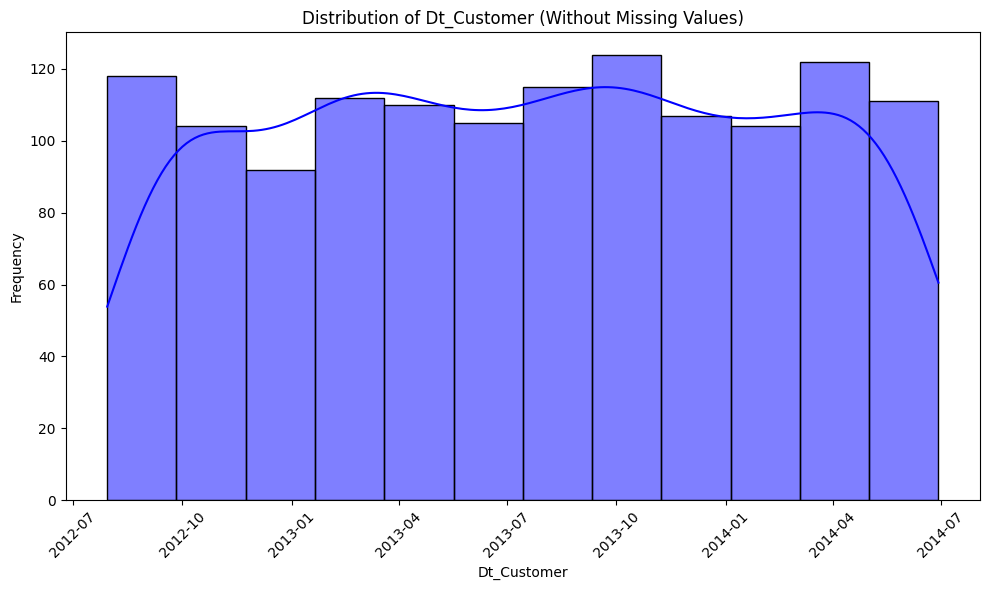

```
### 🗂 Column Analyzed: 'Dt_Customer'

- 📅 Most Frequent Date (Mode): 2012-08-31
- 🔢 Occurrences of Mode: 12
- 📊 Percentage of Mode in Total Non-Null Rows: 0.91%
- 📈 Skewness of Data: -0.01

#### ✅ Conclusion:
- The data is **relatively balanced**.
- There is **no clear skew or dominant mode**.
### 🔧 Recommended Imputation Method:
👉 Use the **median date** → 2013-07-21 for imputing missing values in 'Dt_Customer'.
```

```python
# Column to analyze for Method to be used for Imputation for Dt_Customer
date_column = 'Dt_Customer'

# Step 1: Check for skewness
skewness = PBA_df[date_column].dropna().apply(lambda x: x.timestamp()).skew()

# Step 2: Plot the distribution
plt.figure(figsize=(10, 6))
sns.histplot(PBA_df[date_column].dropna(), kde=True, color='blue')
plt.title(f"Distribution of {date_column} (Without Missing Values)")
plt.xlabel(date_column)
plt.ylabel("Frequency")
plt.xticks(rotation=45)
plt.tight_layout()
plt.show()

# Step 3: Calculate mode, count, and percentage
mode_value = PBA_df[date_column].mode()[0]
mode_count = PBA_df[date_column].value_counts()[mode_value]
total_count = PBA_df[date_column].notna().sum()
mode_percentage = (mode_count / total_count) * 100
median_value = PBA_df[date_column].median()

# Step 4: Final report with recommendation
print("### 🗂 Column Analyzed: 'Dt_Customer'\n")
print(f"- 📅 Most Frequent Date (Mode): {mode_value.date()}")
print(f"- 🔢 Occurrences of Mode: {mode_count}")
print(f"- 📊 Percentage of Mode in Total Non-Null Rows: {mode_percentage:.2f}%")
print(f"- 📈 Skewness of Data: {skewness:.2f}\n")

print("#### ✅ Conclusion:")

if abs(skewness) > 0.5:
    print("- The data is **skewed**.")
    print("- The mode appears in less than 10% of the data and does not dominate.")
    print("### 🔧 Recommended Imputation Method:")
    print(f"👉 Use the **median date** → {median_value.date()} for imputing missing values in 'Dt_Customer'.")
elif mode_percentage > 10:
    print("- The data has a **dominant date value**.")
    print(f"### 🔧 Recommended Imputation Method:")
    print(f"👉 Use the **mode date** → {mode_value.date()} for imputing missing values in 'Dt_Customer'.")
else:
    print("- The data is **relatively balanced**.")
    print("- There is **no clear skew or dominant mode**.")
    print("### 🔧 Recommended Imputation Method:")
    print(f"👉 Use the **median date** → {median_value.date()} for imputing missing values in 'Dt_Customer'.")
```

```python
# Step 1: Calculate the median date
median_date = PBA_df['Dt_Customer'].median()

# Step 2: Impute missing values with the median date
PBA_df['Dt_Customer'] = PBA_df['Dt_Customer'].fillna(median_date)

# Step 3: Optional - Confirm imputation
print(f"✅ Missing values after imputation: {PBA_df['Dt_Customer'].isnull().sum()}")
print(f"🕓 Median date used for imputation: {median_date.date()}")
```

```
✅ Missing values after imputation: 0
🕓 Median date used for imputation: 2013-07-21
```

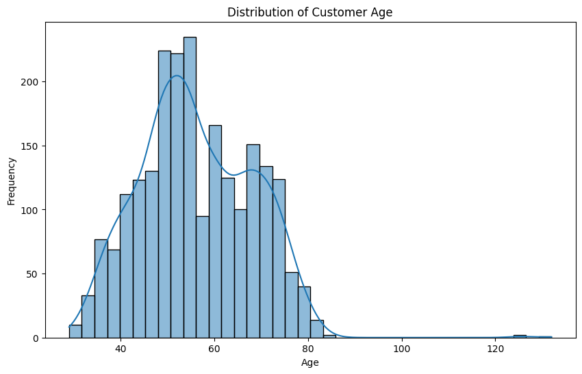

```
count    2240.000000
mean       56.194196
std        11.984069
min        29.000000
25%        48.000000
50%        55.000000
75%        66.000000
max       132.000000
Name: Age, dtype: float64
```

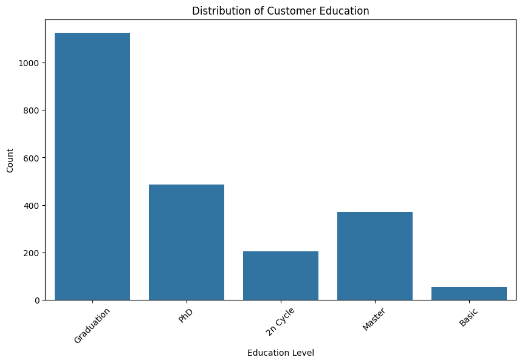

```
Education
Graduation    50.312500
PhD           21.696429
Master        16.517857
2n Cycle       9.062500
Basic          2.410714
Name: proportion, dtype: float64
```

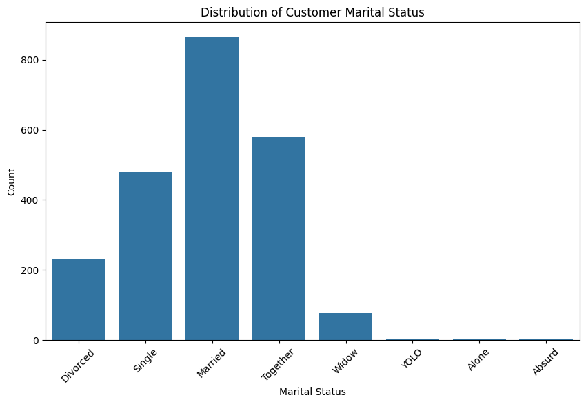

```
Marital_Status
Married     38.571429
Together    25.892857
Single      21.428571
Divorced    10.357143
Widow        3.437500
Alone        0.133929
YOLO         0.089286
Absurd       0.089286
Name: proportion, dtype: float64
```

```python
# Analyze the distribution of customer demographics

# Age distribution
plt.figure(figsize=(10, 6))
sns.histplot(PBA_df['Age'], kde=True)
plt.title('Distribution of Customer Age')
plt.xlabel('Age')
plt.ylabel('Frequency')
plt.show()

print(PBA_df['Age'].describe())

# Education distribution
plt.figure(figsize=(10, 6))
sns.countplot(x='Education', data=PBA_df)
plt.title('Distribution of Customer Education')
plt.xlabel('Education Level')
plt.ylabel('Count')
plt.xticks(rotation=45)
plt.show()

print(PBA_df['Education'].value_counts(normalize=True) * 100)


# Marital status distribution
plt.figure(figsize=(10, 6))
# Check if the column name is 'Marital_Status' instead of 'Marital'
sns.countplot(x='Marital_Status', data=PBA_df)
plt.title('Distribution of Customer Marital Status')
plt.xlabel('Marital Status')
plt.ylabel('Count')
plt.xticks(rotation=45)
plt.show()

print(PBA_df['Marital_Status'].value_counts(normalize=True) * 100) # Print with corrected column name if applicable
```

## Task 2 - Descriptive Statistics 📊

- **Calculate measures of central tendency (mean, median, mode) and measures of dispersion (variance, standard deviation) for key variables. Identify and handle outliers if necessary.**

**Deliverables**:

- **Descriptive statistics that reveal the central tendencies, variations, and potential outliers in the dataset.**:

```python
#Descriptive statistics
# Select all numerical columns
numerical_cols = PBA_df.select_dtypes(include=['int64', 'float64']).columns

# Calculate descriptive statistics
statistics = {}

for col in numerical_cols:
    mean = PBA_df[col].mean()
    median = PBA_df[col].median()
    mode = PBA_df[col].mode()[0] if not PBA_df[col].mode().empty else np.nan
    variance = PBA_df[col].var()
    std_dev = PBA_df[col].std()

    statistics[col] = {
        'Mean': mean,
        'Median': median,
        'Mode': mode,
        'Variance': variance,
        'Standard Deviation': std_dev
    }

# Create DataFrame
stats_df = pd.DataFrame(statistics).T

# Show the table
display(stats_df)
```

|  | Mean | Median | Mode | Variance | Standard Deviation |
| --- | --- | --- | --- | --- | --- |
| Id | 5592.159821 | 5458.5 | 0.0 | 1.054082e+07 | 3246.662198 |
| Year_Birth | 1968.805804 | 1970.0 | 1976.0 | 1.436179e+02 | 11.984069 |
| Income | 52237.975446 | 51381.5 | 51381.5 | 6.268992e+08 | 25037.955891 |
| Kidhome | 0.444196 | 0.0 | 0.0 | 2.898725e-01 | 0.538398 |
| Teenhome | 0.506250 | 0.0 | 0.0 | 2.965219e-01 | 0.544538 |
| Recency | 49.109375 | 49.0 | 56.0 | 8.388237e+02 | 28.962453 |
| MntWines | 303.935714 | 173.5 | 2.0 | 1.132978e+05 | 336.597393 |
| MntFruits | 26.302232 | 8.0 | 0.0 | 1.581926e+03 | 39.773434 |
| MntMeatProducts | 166.950000 | 67.0 | 7.0 | 5.094743e+04 | 225.715373 |
| MntFishProducts | 37.525446 | 12.0 | 0.0 | 2.984325e+03 | 54.628979 |
| MntSweetProducts | 27.062946 | 8.0 | 0.0 | 1.704080e+03 | 41.280498 |
| MntGoldProds | 44.021875 | 24.0 | 1.0 | 2.721442e+03 | 52.167439 |
| NumDealsPurchases | 2.325000 | 2.0 | 1.0 | 3.733542e+00 | 1.932238 |
| NumWebPurchases | 4.084821 | 4.0 | 2.0 | 7.721252e+00 | 2.778714 |
| NumCatalogPurchases | 2.662054 | 2.0 | 0.0 | 8.544517e+00 | 2.923101 |
| NumStorePurchases | 5.790179 | 5.0 | 3.0 | 1.056873e+01 | 3.250958 |
| NumWebVisitsMonth | 5.316518 | 6.0 | 7.0 | 5.888606e+00 | 2.426645 |
| Response | 0.149107 | 0.0 | 0.0 | 1.269309e-01 | 0.356274 |
| Complain | 0.009375 | 0.0 | 0.0 | 9.291257e-03 | 0.096391 |
| Age | 56.194196 | 55.0 | 49.0 | 1.436179e+02 | 11.984069 |
| TotalSpend | 605.798214 | 396.0 | 46.0 | 3.627042e+05 | 602.249288 |

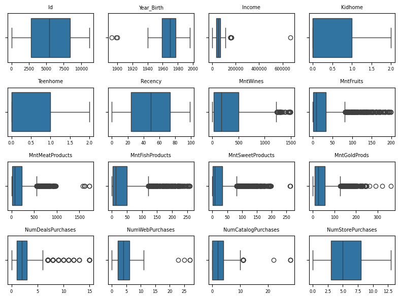

```python
 #Box plot of outliers in various columns
# Select numerical columns (excluding 'ID')
numerical_cols = PBA_df.select_dtypes(include=['number']).drop(columns=['ID'], errors='ignore').columns[:16]

# Create 4x4 subplots with a much smaller figure size
fig, axes = plt.subplots(nrows=4, ncols=4, figsize=(8, 6))  # Much smaller
axes = axes.flatten()

# Create box plots
for i, col in enumerate(numerical_cols):
    sns.boxplot(x=PBA_df[col], ax=axes[i])
    axes[i].set_title(f'{col}', fontsize=7)
    axes[i].set_xlabel('')
    axes[i].tick_params(labelsize=6)

# Hide any unused subplots
for j in range(i + 1, len(axes)):
    axes[j].axis('off')

plt.tight_layout()
plt.show()
```

### **Finding method to be used for Outliers handling**

```python
# Finding Best Method for Handling Outliers
# Select numerical columns for analysis
num_cols = PBA_df.select_dtypes(include=['float64', 'int64']).columns

# Initialize counters for outlier categories
mild_outlier_count = 0
severe_outlier_count = 0

# Ensure the stats module is imported
from scipy import stats
import numpy as np # Also ensure numpy is imported as it's used with np.abs

# Helper functions for outlier detection
def calculate_outliers_iqr(column):
    Q1 = column.quantile(0.25)
    Q3 = column.quantile(0.75)
    IQR = Q3 - Q1
    lower = Q1 - 1.5 * IQR
    upper = Q3 + 1.5 * IQR
    return lower, upper, (column < lower) | (column > upper)

def calculate_outliers_zscore(column, threshold=3):
    z_scores = np.abs(stats.zscore(column, nan_policy='omit'))
    return z_scores > threshold

def apply_winsorization(column, lower_percentile=0.01, upper_percentile=0.99):
    lower_limit = column.quantile(lower_percentile)
    upper_limit = column.quantile(upper_percentile)
    return column.clip(lower=lower_limit, upper=upper_limit)

# Evaluation of all methods
outlier_details = {}

for col in num_cols:
    # Check if the column has non-null values to avoid errors with empty columns
    if PBA_df[col].notna().sum() == 0:
        print(f"Skipping outlier analysis for empty column: {col}")
        continue

    # IQR Method
    # Ensure column has at least 2 non-null values for quantile calculation
    if PBA_df[col].notna().sum() >= 2:
        lower_iqr, upper_iqr, iqr_outliers = calculate_outliers_iqr(PBA_df[col])
        iqr_outlier_count = iqr_outliers.sum()
    else:
        iqr_outlier_count = 0 # No outliers if less than 2 data points

    # Z-Score Method
    # Ensure column has at least 2 non-null values for zscore calculation
    if PBA_df[col].notna().sum() >= 2:
        zscore_outliers = calculate_outliers_zscore(PBA_df[col])
        zscore_outlier_count = zscore_outliers.sum()
    else:
        zscore_outlier_count = 0 # No outliers if less than 2 data points


    # Winsorization (applying capping)
    # Ensure column has non-null values before applying winsorization
    if PBA_df[col].notna().sum() > 0:
        winsorized_column = apply_winsorization(PBA_df[col])
        winsorized_outliers = (PBA_df[col] != winsorized_column).sum()
    else:
        winsorized_outliers = 0 # No outliers if no data points

    # Outlier ratio (outliers relative to non-null entries)
    total_non_null_entries = PBA_df[col].notna().sum()
    outlier_ratio_iqr = iqr_outlier_count / total_non_null_entries if total_non_null_entries > 0 else 0
    outlier_ratio_zscore = zscore_outlier_count / total_non_null_entries if total_non_null_entries > 0 else 0
    outlier_ratio_winsorization = winsorized_outliers / total_non_null_entries if total_non_null_entries > 0 else 0

    # Track results for decision making
    outlier_details[col] = {
        "IQR Outliers": iqr_outlier_count,
        "Z-Score Outliers": zscore_outlier_count,
        "Winsorization Outliers": winsorized_outliers,
        "Outlier Ratio IQR": outlier_ratio_iqr,
        "Outlier Ratio Z-Score": outlier_ratio_zscore,
        "Outlier Ratio Winsorization": outlier_ratio_winsorization
    }

# Total summary of outlier methods across all columns
total_outliers_iqr = sum([outlier_details[col]["IQR Outliers"] for col in num_cols if col in outlier_details])
total_outliers_zscore = sum([outlier_details[col]["Z-Score Outliers"] for col in num_cols if col in outlier_details])
total_outliers_winsorization = sum([outlier_details[col]["Winsorization Outliers"] for col in num_cols if col in outlier_details])

# Suggesting best method based on criteria
threshold_for_mild_outliers = 0.05
threshold_for_severe_outliers = 0.15

# Calculate the number of columns with outliers based on IQR, Z-Score, and Winsorization
mild_outliers = sum(1 for col in num_cols if col in outlier_details and outlier_details[col]["Outlier Ratio IQR"] > threshold_for_mild_outliers)
severe_outliers = sum(1 for col in num_cols if col in outlier_details and outlier_details[col]["Outlier Ratio IQR"] > threshold_for_severe_outliers)

# Decision logic considering business context and outlier severity
if severe_outliers > len(num_cols) * 0.3:
    print("Suggested outlier-handling method for PBA_df: Transformation (log/sqrt)")
elif mild_outliers > 0:
    # Adding business context: Retail/Purchasing market where extreme values represent genuine customers
    print("Suggested outlier-handling method for PBA_df: Winsorization (capping).")
    print("\n")
    print("""This is a retail/purchasing dataset, where extreme values often represent genuine high-spending customers,
and removing them could result in loss of important information. Hence, Winsorization is a more suitable approach.""")

else:
    print("Suggested outlier-handling method for PBA_df: No action needed")

# Displaying the summary of the outlier methods
print("\nOutlier detection summary across all numerical columns:")
print(f"Total Outliers (IQR): {total_outliers_iqr}")
print(f"Total Outliers (Z-Score): {total_outliers_zscore}")
print(f"Total Outliers (Winsorization): {total_outliers_winsorization}")
```

```
Suggested outlier-handling method for PBA_df: Winsorization (capping).


This is a retail/purchasing dataset, where extreme values often represent genuine high-spending customers,
and removing them could result in loss of important information. Hence, Winsorization is a more suitable approach.

Outlier detection summary across all numerical columns:
Total Outliers (IQR): 1608
Total Outliers (Z-Score): 370
Total Outliers (Winsorization): 493
```

### **Handling Outliers**

```python
# Winsozarion for handling Outliers
def winsorize_outliers(df, columns, limits=(0.05, 0.95)):
    """Applies Winsorization to specified columns in a DataFrame."""
    df_winsorized = df.copy()
    for col in columns:
        lower = df[col].quantile(limits[0])
        upper = df[col].quantile(limits[1])
        df_winsorized[col] = np.clip(df[col], lower, upper)
    return df_winsorized

columns_to_winsorize = [
    'Income', 'MntWines', 'MntFruits', 'MntMeatProducts',
    'MntFishProducts', 'MntSweetProducts', 'MntGoldProds',
    'NumDealsPurchases', 'NumWebPurchases', 'NumCatalogPurchases',
    'NumStorePurchases', 'NumWebVisitsMonth', 'Recency', 'Age'
]

PBA_df_winsorized = winsorize_outliers(PBA_df, columns_to_winsorize)
```

```python
# Winsozarion for handling Outliers
def winsorize_outliers(df, columns, limits=(0.05, 0.95)):
    """Applies Winsorization to specified columns in a DataFrame."""
    df_winsorized = df.copy()
    for col in columns:
        # Check if the column exists before trying to winsorize
        if col in df_winsorized.columns:
            lower = df_winsorized[col].quantile(limits[0])
            upper = df_winsorized[col].quantile(limits[1])
            df_winsorized[col] = np.clip(df_winsorized[col], lower, upper)
        else:
            print(f"Warning: Column '{col}' not found in DataFrame for winsorization.")
    return df_winsorized

columns_to_winsorize = [
    'Income', 'MntWines', 'MntFruits', 'MntMeatProducts',
    'MntFishProducts', 'MntSweetProducts', 'MntGoldProds',
    'NumDealsPurchases', 'NumWebPurchases', 'NumCatalogPurchases',
    'NumStorePurchases', 'NumWebVisitsMonth', 'Recency', 'Age'
]

PBA_df_winsorized = winsorize_outliers(PBA_df, columns_to_winsorize)

# Recalculate 'TotalSpend' after Winsorization using the winsorized spending columns
# Ensure these columns exist in the winsorized dataframe before summing
spending_cols = ['MntFishProducts', 'MntMeatProducts', 'MntFruits', 'MntSweetProducts', 'MntWines', 'MntGoldProds']
# Check if spending columns exist in the winsorized dataframe before summing
existing_spending_cols = [col for col in spending_cols if col in PBA_df_winsorized.columns]

if existing_spending_cols:
    PBA_df_winsorized['TotalSpend'] = PBA_df_winsorized[existing_spending_cols].sum(axis=1)
else:
    print("Warning: No spending columns found in PBA_df_winsorized to calculate TotalSpend.")
```

### **Box plot after handling Outliers**

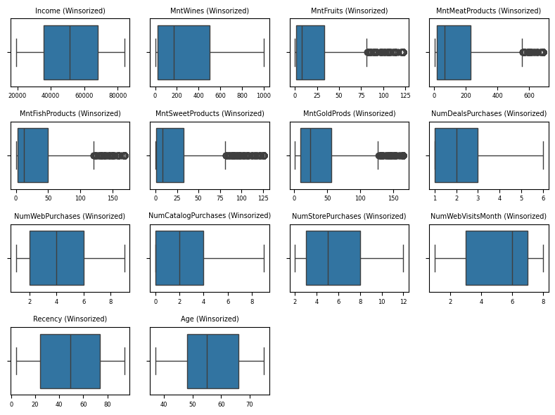

```python
# Create subplots for box plots after winsorization
fig, axes = plt.subplots(nrows=4, ncols=4, figsize=(8, 6))
axes = axes.flatten()

# Iterate through numerical columns and create box plots for winsorized data
for i, col in enumerate(columns_to_winsorize):
    if i < len(axes):
        sns.boxplot(x=PBA_df_winsorized[col], ax=axes[i])
        axes[i].set_title(f'{col} (Winsorized)', fontsize=7)
        axes[i].set_xlabel('')
        axes[i].tick_params(labelsize=6)
    else:
        break

# Hide any unused subplots
for j in range(i + 1, len(axes)):
    axes[j].axis('off')

plt.tight_layout()
plt.show()
```

### **Descriptive Statistics comparison after Winsorization**

```python
# Select numerical columns
numerical_cols = PBA_df.select_dtypes(include=['int64', 'float64']).columns

# Helper function to compute statistics
def get_statistics(df):
    stats = {}
    for col in numerical_cols:
        mode_val = df[col].mode()[0] if not df[col].mode().empty else np.nan
        stats[col] = {
            'Mean': df[col].mean(),
            'Median': df[col].median(),
            'Mode': mode_val,
            'Variance': df[col].var(),
            'Standard Deviation': df[col].std()
        }
    return pd.DataFrame(stats).T

# Stats before Winsorization
stats_before = get_statistics(PBA_df)

# Apply Winsorization (limit 5% on each side)
winsorized_df = PBA_df.copy()
for col in numerical_cols:
    winsorized_data = winsorize(PBA_df[col], limits=[0.05, 0.05])
    winsorized_df[col] = winsorized_data

# Stats after Winsorization
stats_after = get_statistics(winsorized_df)

# Combine both for comparison
combined_stats = pd.DataFrame()
for stat in ['Mean', 'Median', 'Mode', 'Variance', 'Standard Deviation']:
    combined_stats[f'{stat} (Before)'] = stats_before[stat]
    combined_stats[f'{stat} (After)'] = stats_after[stat]

# Display the final comparison table
display(combined_stats)
```

|  | Mean (Before) | Mean (After) | Median (Before) | Median (After) | Mode (Before) | Mode (After) | Variance (Before) | Variance (After) | Standard Deviation (Before) | Standard Deviation (After) |
| --- | --- | --- | --- | --- | --- | --- | --- | --- | --- | --- |
| Id | 5592.159821 | 5594.921875 | 5458.5 | 5458.5 | 0.0 | 577.0 | 1.054082e+07 | 1.026318e+07 | 3246.662198 | 3203.619651 |
| Year_Birth | 1968.805804 | 1968.910714 | 1970.0 | 1970.0 | 1976.0 | 1950.0 | 1.436179e+02 | 1.260715e+02 | 11.984069 | 11.228158 |
| Income | 52237.975446 | 51743.179911 | 51381.5 | 51381.5 | 51381.5 | 19107.0 | 6.268992e+08 | 3.857132e+08 | 25037.955891 | 19639.582044 |
| Kidhome | 0.444196 | 0.422768 | 0.0 | 0.0 | 0.0 | 0.0 | 2.898725e-01 | 2.441442e-01 | 0.538398 | 0.494109 |
| Teenhome | 0.506250 | 0.483036 | 0.0 | 0.0 | 0.0 | 0.0 | 2.965219e-01 | 2.498237e-01 | 0.544538 | 0.499824 |
| Recency | 49.109375 | 49.094643 | 49.0 | 49.0 | 56.0 | 4.0 | 8.388237e+02 | 8.150344e+02 | 28.962453 | 28.548807 |
| MntWines | 303.935714 | 295.352679 | 173.5 | 173.5 | 2.0 | 3.0 | 1.132978e+05 | 9.869085e+04 | 336.597393 | 314.151003 |
| MntFruits | 26.302232 | 24.774107 | 8.0 | 8.0 | 0.0 | 0.0 | 1.581926e+03 | 1.215066e+03 | 39.773434 | 34.857790 |
| MntMeatProducts | 166.950000 | 159.041964 | 67.0 | 67.0 | 7.0 | 4.0 | 5.094743e+04 | 3.944467e+04 | 225.715373 | 198.606827 |
| MntFishProducts | 37.525446 | 35.656696 | 12.0 | 12.0 | 0.0 | 0.0 | 2.984325e+03 | 2.391898e+03 | 54.628979 | 48.907031 |
| MntSweetProducts | 27.062946 | 25.435268 | 8.0 | 8.0 | 0.0 | 0.0 | 1.704080e+03 | 1.295957e+03 | 41.280498 | 35.999396 |
| MntGoldProds | 44.021875 | 42.175893 | 24.0 | 24.0 | 1.0 | 1.0 | 2.721442e+03 | 2.139522e+03 | 52.167439 | 46.254962 |
| NumDealsPurchases | 2.325000 | 2.236161 | 2.0 | 2.0 | 1.0 | 1.0 | 3.733542e+00 | 2.296593e+00 | 1.932238 | 1.515451 |
| NumWebPurchases | 4.084821 | 4.018750 | 4.0 | 4.0 | 2.0 | 1.0 | 7.721252e+00 | 6.105946e+00 | 2.778714 | 2.471021 |
| NumCatalogPurchases | 2.662054 | 2.592411 | 2.0 | 2.0 | 0.0 | 0.0 | 8.544517e+00 | 7.041925e+00 | 2.923101 | 2.653663 |
| NumStorePurchases | 5.790179 | 5.769643 | 5.0 | 5.0 | 3.0 | 3.0 | 1.056873e+01 | 9.915648e+00 | 3.250958 | 3.148912 |
| NumWebVisitsMonth | 5.316518 | 5.244196 | 6.0 | 6.0 | 7.0 | 8.0 | 5.888606e+00 | 4.998403e+00 | 2.426645 | 2.235711 |
| Response | 0.149107 | 0.149107 | 0.0 | 0.0 | 0.0 | 0.0 | 1.269309e-01 | 1.269309e-01 | 0.356274 | 0.356274 |
| Complain | 0.009375 | 0.000000 | 0.0 | 0.0 | 0.0 | 0.0 | 9.291257e-03 | 0.000000e+00 | 0.096391 | 0.000000 |
| Age | 56.194196 | 56.089286 | 55.0 | 55.0 | 49.0 | 75.0 | 1.436179e+02 | 1.260715e+02 | 11.984069 | 11.228158 |
| TotalSpend | 605.798214 | 594.263393 | 396.0 | 396.0 | 46.0 | 22.0 | 3.627042e+05 | 3.301940e+05 | 602.249288 | 574.625116 |

## Task 3 - Probability Distributions 🎲

- **Identify variables that could follow specific probability distributions (e.g., Binomial, Normal). Calculate probabilities and expected values based on these distributions.**

**Deliverables**:

- **Determination of suitable probability distributions for relevant variables and corresponding calculated probabilities and expected values.**:

```
📌 Bernoulli Distribution: Binary Variables
```

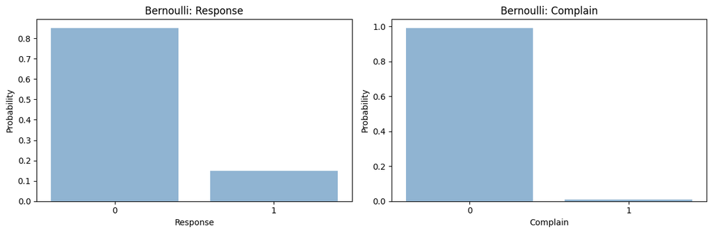

```
📌 Normal Distribution: Spend Variables
```

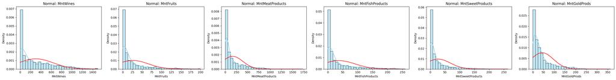

```
📌 Poisson Distribution: Count Variables
```

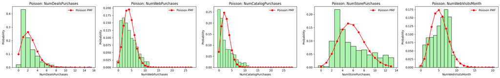

```
📌 Categorical Distribution: Education and Marital Status
```

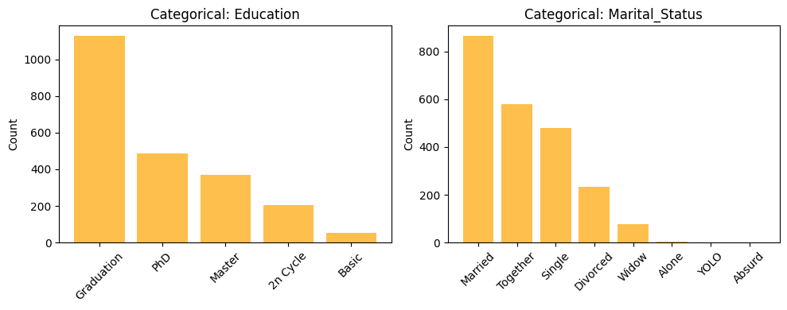

```
📌 Demographic Variables: Income, Age, Recency, Kidhome, Teenhome
```

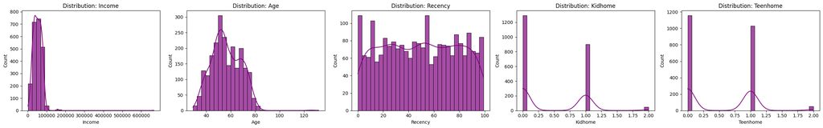

```
📌 Exponential Fit: Recency
```

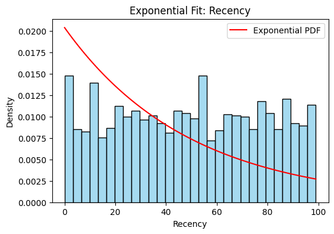

```python
#Probability Distributions
df = PBA_df  # Using your DataFrame

# ---------------------------
# 1. Bernoulli Distribution
# ---------------------------
print("📌 Bernoulli Distribution: Binary Variables\n")
binary_vars = ['Response', 'Complain']
fig, axs = plt.subplots(1, len(binary_vars), figsize=(6 * len(binary_vars), 4))

for i, var in enumerate(binary_vars):
    data = df[var].dropna()
    if data.nunique() > 1:
        prob = data.mean()
        pmf = stats.bernoulli.pmf([0, 1], prob)

        axs[i].bar([0, 1], pmf, alpha=0.6, color='steelblue')
        axs[i].set_title(f'Bernoulli: {var}')
        axs[i].set_xlabel(var)
        axs[i].set_ylabel('Probability')
        axs[i].set_xticks([0, 1])

plt.tight_layout()
plt.show()

# ---------------------------
# 2. Normal Distribution
# ---------------------------
print("📌 Normal Distribution: Spend Variables\n")
normal_vars = ['MntWines', 'MntFruits', 'MntMeatProducts', 'MntFishProducts', 'MntSweetProducts', 'MntGoldProds']
fig, axs = plt.subplots(1, len(normal_vars), figsize=(5 * len(normal_vars), 4))

for i, var in enumerate(normal_vars):
    data = df[var].dropna()
    mean, std = data.mean(), data.std()
    sns.histplot(data, kde=True, stat='density', bins=30, ax=axs[i], color='skyblue')
    x = np.linspace(data.min(), data.max(), 100)
    axs[i].plot(x, stats.norm.pdf(x, mean, std), 'r')
    axs[i].set_title(f'Normal: {var}')
    axs[i].set_xlabel(var)

plt.tight_layout()
plt.show()

# ---------------------------
# 3. Poisson Distribution
# ---------------------------
print("📌 Poisson Distribution: Count Variables\n")
poisson_vars = ['NumDealsPurchases', 'NumWebPurchases',
                'NumCatalogPurchases', 'NumStorePurchases', 'NumWebVisitsMonth']
fig, axs = plt.subplots(1, len(poisson_vars), figsize=(5 * len(poisson_vars), 4))

for i, var in enumerate(poisson_vars):
    data = df[var].dropna()
    lam = data.mean()
    values = np.arange(data.min(), data.max() + 1)
    probs = stats.poisson.pmf(values, mu=lam)

    sns.histplot(data, stat='probability', bins=len(values), discrete=True, color='lightgreen', ax=axs[i])
    axs[i].plot(values, probs, 'o-', color='red', label='Poisson PMF')
    axs[i].set_title(f'Poisson: {var}')
    axs[i].set_xlabel(var)
    axs[i].legend()

plt.tight_layout()
plt.show()

# ---------------------------
# 4. Categorical Variables
# ---------------------------
print("📌 Categorical Distribution: Education and Marital Status\n")
categorical_vars = ['Education', 'Marital_Status']
fig, axs = plt.subplots(1, len(categorical_vars), figsize=(5 * len(categorical_vars), 4))

for i, var in enumerate(categorical_vars):
    counts = df[var].value_counts()
    axs[i].bar(counts.index, counts.values, color='orange', alpha=0.7)
    axs[i].set_title(f'Categorical: {var}')
    axs[i].set_ylabel('Count')
    axs[i].tick_params(axis='x', rotation=45)

plt.tight_layout()
plt.show()

# ---------------------------
# 5. Demographic Distributions
# ---------------------------
print("📌 Demographic Variables: Income, Age, Recency, Kidhome, Teenhome\n")
demographic_vars = ['Income', 'Age', 'Recency', 'Kidhome', 'Teenhome']
fig, axs = plt.subplots(1, len(demographic_vars), figsize=(5 * len(demographic_vars), 4))

for i, var in enumerate(demographic_vars):
    sns.histplot(df[var].dropna(), bins=30, kde=True, color='purple', ax=axs[i], alpha=0.7)
    axs[i].set_title(f'Distribution: {var}')
    axs[i].set_xlabel(var)

plt.tight_layout()
plt.show()

# ---------------------------
# 6. Exponential Fit for Recency
# ---------------------------
print("📌 Exponential Fit: Recency\n")
fig, ax = plt.subplots(figsize=(6, 4))
recency_data = df['Recency'].dropna()
scale = recency_data.mean()

sns.histplot(recency_data, stat='density', bins=30, color='skyblue', ax=ax)
x = np.linspace(0, recency_data.max(), 100)
ax.plot(x, stats.expon.pdf(x, scale=scale), 'r', label='Exponential PDF')
ax.set_title('Exponential Fit: Recency')
ax.set_xlabel('Recency')
ax.set_ylabel('Density')
ax.legend()
plt.show()
```

### **Calculate probabilities and expected values based on these distributions.**

```python
#Probabilities and expected values based on these distributions

df = PBA_df
results = []

# Helper function to append results with interpretation
def append_result(dist, var, prob, exp_val, interpretation):
    # Shorten and format probability output if needed
    if isinstance(prob, dict):
        prob = {k: round(v, 3) for k, v in list(prob.items())[:5]}  # limit to first 5 categories
    elif hasattr(prob, '__iter__') and not isinstance(prob, str):
        prob = [round(p, 4) for p in prob[:5]]  # limit and round
    results.append({
        'Distribution': dist,
        'Variable': var,
        'Probability': prob,
        'Expected Value': round(exp_val, 2) if pd.notnull(exp_val) and not isinstance(exp_val, str) else exp_val,
        'Interpretation': interpretation
    })

# 1. Bernoulli
for var in ['Response', 'Complain']:
    data = df[var].dropna()
    if data.nunique() > 1:
        p = data.mean()
        append_result('Bernoulli', var, p, p, 'Probability of event (Yes = 1)')

# 2. Normal
for var in ['MntWines', 'MntFruits', 'MntMeatProducts', 'MntFishProducts', 'MntSweetProducts', 'MntGoldProds']:
    data = df[var].dropna()
    append_result('Normal', var, None, data.mean(), 'Avg spend (₹/Customer)')

# 3. Poisson
for var in ['NumDealsPurchases', 'NumWebPurchases', 'NumCatalogPurchases', 'NumStorePurchases', 'NumWebVisitsMonth']:
    data = df[var].dropna()
    append_result('Poisson', var, None, data.mean(), 'Avg count (/Customer)')

# 4. Categorical
for var in ['Education', 'Marital_Status']:
    counts = df[var].value_counts()
    probs = counts / counts.sum()
    append_result('Categorical', var, probs.to_dict(), 'N/A', 'Probability distribution of categories')

# 5. Demographics
for var in ['Income', 'Age', 'Recency', 'Kidhome', 'Teenhome']:
    data = df[var].dropna()
    probs = stats.gaussian_kde(data)(data)
    interpretation = 'Mean value (/Customer)' if var not in ['Kidhome', 'Teenhome'] else 'Avg count (/Customer)'
    append_result('Demographic', var, probs, data.mean(), interpretation)

# 6. Exponential
recency = df['Recency'].dropna()
append_result('Exponential', 'Recency', None, recency.mean(), 'Avg recency (/Customer)')

# Output clean DataFrame
results_df = pd.DataFrame(results)

# Use pandas display options for better formatting
pd.set_option('display.max_rows', None)  # Display all rows
pd.set_option('display.max_columns', None) # Display all columns
pd.set_option('display.width', None) # Allow wider display
pd.set_option('display.colheader_justify', 'center') # Center headers
pd.set_option('display.precision', 2) # Set floating point precision

print("Probability and Expected Value Calculation Summary:")
display(results_df)
```

```
Probability and Expected Value Calculation Summary:
```

|  | Distribution | Variable | Probability | Expected Value | Interpretation |
| --- | --- | --- | --- | --- | --- |
| 0 | Bernoulli | Response | 0.15 | 0.15 | Probability of event (Yes = 1) |
| 1 | Bernoulli | Complain | 0.01 | 0.01 | Probability of event (Yes = 1) |
| 2 | Normal | MntWines | None | 303.94 | Avg spend (₹/Customer) |
| 3 | Normal | MntFruits | None | 26.3 | Avg spend (₹/Customer) |
| 4 | Normal | MntMeatProducts | None | 166.95 | Avg spend (₹/Customer) |
| 5 | Normal | MntFishProducts | None | 37.53 | Avg spend (₹/Customer) |
| 6 | Normal | MntSweetProducts | None | 27.06 | Avg spend (₹/Customer) |
| 7 | Normal | MntGoldProds | None | 44.02 | Avg spend (₹/Customer) |
| 8 | Poisson | NumDealsPurchases | None | 2.33 | Avg count (/Customer) |
| 9 | Poisson | NumWebPurchases | None | 4.08 | Avg count (/Customer) |
| 10 | Poisson | NumCatalogPurchases | None | 2.66 | Avg count (/Customer) |
| 11 | Poisson | NumStorePurchases | None | 5.79 | Avg count (/Customer) |
| 12 | Poisson | NumWebVisitsMonth | None | 5.32 | Avg count (/Customer) |
| 13 | Categorical | Education | {'Graduation': 0.503, 'PhD': 0.217, 'Master': ... | N/A | Probability distribution of categories |
| 14 | Categorical | Marital_Status | {'Married': 0.386, 'Together': 0.259, 'Single'... | N/A | Probability distribution of categories |
| 15 | Demographic | Income | [0.0, 0.0, 0.0, 0.0, 0.0] | 52237.98 | Mean value (/Customer) |
| 16 | Demographic | Age | [0.0312, 0.0209, 0.0215, 0.0259, 0.0107] | 56.19 | Mean value (/Customer) |
| 17 | Demographic | Recency | [0.0057, 0.0057, 0.0057, 0.0057, 0.0057] | 49.11 | Mean value (/Customer) |
| 18 | Demographic | Kidhome | [2.0008, 2.0008, 2.0008, 1.3911, 1.3911] | 0.44 | Avg count (/Customer) |
| 19 | Demographic | Teenhome | [1.7717, 1.7717, 1.5759, 1.5759, 1.7717] | 0.51 | Avg count (/Customer) |
| 20 | Exponential | Recency | None | 49.11 | Avg recency (/Customer) |

## Task 4: Insights and Customer Segmentation 📈

- **Explore relationships between customer characteristics and spending habits. Segment customers based on their behaviors and characteristics.**

**Deliverables**:

- **Key insights regarding relationships between variables and distinct customer segments based on behaviors.**

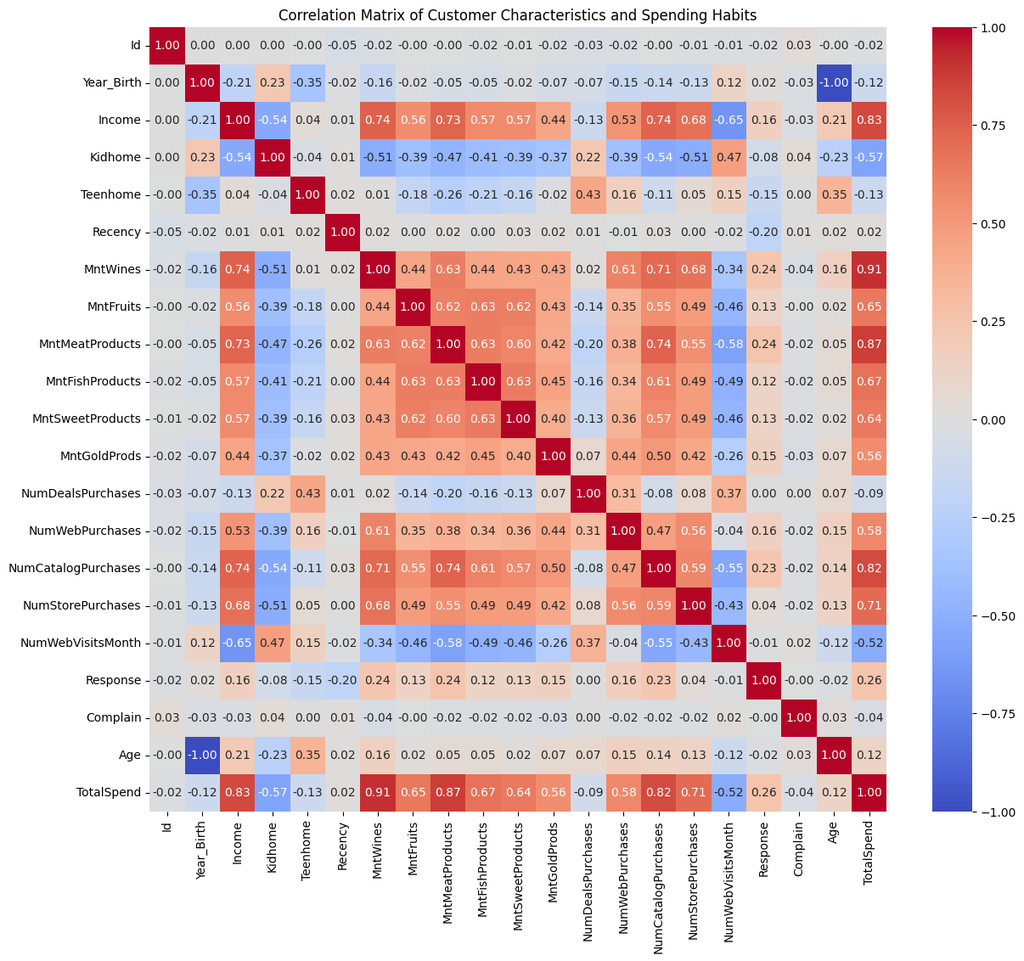

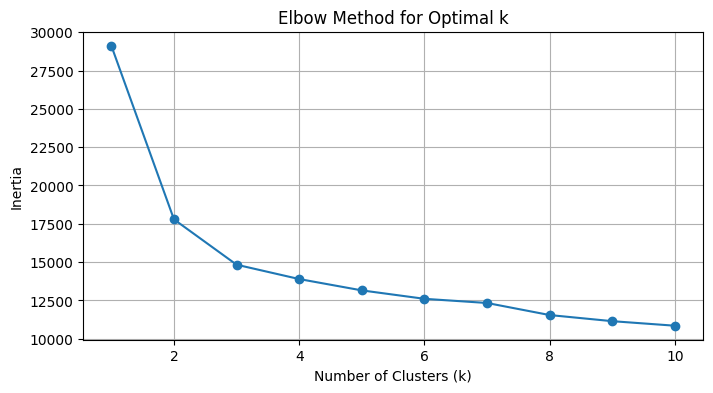

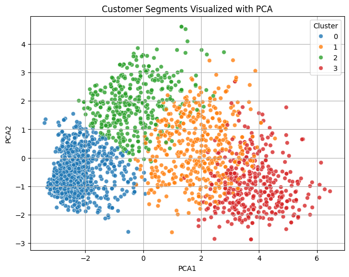

```
📊 Average feature values per cluster:
```

| Cluster | Income | Age | MntWines | MntFruits | MntMeatProducts | MntFishProducts | MntSweetProducts | MntGoldProds | NumDealsPurchases | NumWebPurchases | NumCatalogPurchases | NumStorePurchases | NumWebVisitsMonth |
| --- | --- | --- | --- | --- | --- | --- | --- | --- | --- | --- | --- | --- | --- |
| 0 | 35008.4 | 53.7 | 36.0 | 4.6 | 21.5 | 6.8 | 4.8 | 14.2 | 1.9 | 2.0 | 0.5 | 3.2 | 6.2 |
| 1 | 68079.1 | 59.0 | 572.6 | 32.3 | 244.3 | 48.4 | 35.3 | 57.2 | 2.0 | 5.7 | 4.5 | 8.7 | 4.1 |
| 2 | 50906.0 | 59.4 | 357.5 | 12.6 | 95.4 | 18.6 | 13.1 | 54.6 | 4.4 | 6.0 | 2.2 | 6.4 | 6.8 |
| 3 | 75146.6 | 56.0 | 557.6 | 77.8 | 462.7 | 109.0 | 77.2 | 82.0 | 1.3 | 5.1 | 5.8 | 8.3 | 2.7 |

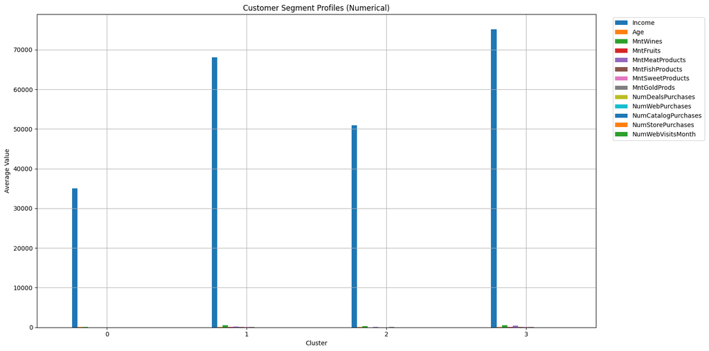

```
📌 Cluster Distribution by Marital Status:
```

| Marital_Status Cluster | Absurd | Alone | Divorced | Married | Single | Together | Widow | YOLO |
| --- | --- | --- | --- | --- | --- | --- | --- | --- |
| 0 | 0 | 2 | 96 | 389 | 223 | 257 | 24 | 0 |
| 1 | 0 | 0 | 53 | 183 | 90 | 121 | 15 | 0 |
| 2 | 0 | 1 | 44 | 149 | 71 | 102 | 18 | 2 |
| 3 | 2 | 0 | 39 | 143 | 96 | 100 | 20 | 0 |

```
📌 Cluster Distribution by Education:
```

| Education Cluster | 2n Cycle | Basic | Graduation | Master | PhD |
| --- | --- | --- | --- | --- | --- |
| 0 | 108 | 52 | 483 | 163 | 185 |
| 1 | 32 | 0 | 208 | 80 | 142 |
| 2 | 24 | 2 | 187 | 75 | 99 |
| 3 | 39 | 0 | 249 | 52 | 60 |

```
📌 Average Kids and Teens at Home per Cluster:
```

| Cluster | Kidhome | Teenhome |
| --- | --- | --- |
| 0 | 0.76 | 0.45 |
| 1 | 0.11 | 0.57 |
| 2 | 0.47 | 0.90 |
| 3 | 0.02 | 0.20 |

[output not shown]

```python
# -----------------------------------------------
# STEP 1: Correlation Heatmap
# -----------------------------------------------
PBA_df_winsorized['Age'] = 2025 - PBA_df_winsorized['Year_Birth']
numerical_features = PBA_df_winsorized.select_dtypes(include='number').columns
correlation_matrix = PBA_df_winsorized[numerical_features].corr()

plt.figure(figsize=(14, 12))
sns.heatmap(correlation_matrix, annot=True, cmap='coolwarm', fmt=".2f")
plt.title('Correlation Matrix of Customer Characteristics and Spending Habits')
plt.show()

# -----------------------------------------------
# STEP 2: KMeans Segmentation
# -----------------------------------------------
features = ['Income', 'Age', 'MntWines', 'MntFruits', 'MntMeatProducts',
            'MntFishProducts', 'MntSweetProducts', 'MntGoldProds',
            'NumDealsPurchases', 'NumWebPurchases', 'NumCatalogPurchases',
            'NumStorePurchases', 'NumWebVisitsMonth']

scaler = StandardScaler()
scaled_features = scaler.fit_transform(PBA_df_winsorized[features])

# Elbow Method
inertia = []
for k in range(1, 11):
    kmeans = KMeans(n_clusters=k, random_state=42)
    kmeans.fit(scaled_features)
    inertia.append(kmeans.inertia_)

plt.figure(figsize=(8, 4))
plt.plot(range(1, 11), inertia, marker='o')
plt.title('Elbow Method for Optimal k')
plt.xlabel('Number of Clusters (k)')
plt.ylabel('Inertia')
plt.grid(True)
plt.show()

# Apply KMeans with chosen k (e.g., 4)
optimal_k = 4
kmeans = KMeans(n_clusters=optimal_k, random_state=42)
PBA_df_winsorized['Cluster'] = kmeans.fit_predict(scaled_features)

# -----------------------------------------------
# STEP 3: PCA Scatterplot
# -----------------------------------------------
pca = PCA(n_components=2)
pca_components = pca.fit_transform(scaled_features)
PBA_df_winsorized['PCA1'] = pca_components[:, 0]
PBA_df_winsorized['PCA2'] = pca_components[:, 1]

plt.figure(figsize=(8, 6))
sns.scatterplot(data=PBA_df_winsorized, x='PCA1', y='PCA2', hue='Cluster', palette='tab10', alpha=0.8)
plt.title('Customer Segments Visualized with PCA')
plt.xlabel('PCA1')
plt.ylabel('PCA2')
plt.legend(title='Cluster')
plt.grid(True)
plt.show()

# -----------------------------------------------
# STEP 4: Bar Plot - Cluster Means
# -----------------------------------------------
cluster_means = PBA_df_winsorized.groupby('Cluster')[features].mean().round(1)
print("📊 Average feature values per cluster:")
display(cluster_means)

cluster_means.plot(kind='bar', figsize=(16, 8))
plt.title('Customer Segment Profiles (Numerical)')
plt.xlabel('Cluster')
plt.ylabel('Average Value')
plt.xticks(rotation=0)
plt.legend(loc='upper right', bbox_to_anchor=(1.2, 1))
plt.grid(True)
plt.tight_layout()
plt.show()

# -----------------------------------------------
# STEP 5: Cluster Demographics Summary
# -----------------------------------------------
print("\n📌 Cluster Distribution by Marital Status:")
display(pd.crosstab(PBA_df_winsorized['Cluster'], PBA_df_winsorized['Marital_Status']))

print("\n📌 Cluster Distribution by Education:")
display(pd.crosstab(PBA_df_winsorized['Cluster'], PBA_df_winsorized['Education']))

print("\n📌 Average Kids and Teens at Home per Cluster:")
display(PBA_df_winsorized.groupby('Cluster')[['Kidhome', 'Teenhome']].mean().round(2))

# -----------------------------------------------
# STEP 6: Generate Segment Summary Table
# -----------------------------------------------
def generate_segment_summary(df, cluster_col='Cluster'):
    summaries = []

    features = ['Income', 'Age', 'MntWines', 'MntFruits', 'MntMeatProducts',
                'MntFishProducts', 'MntSweetProducts', 'MntGoldProds',
                'NumDealsPurchases', 'NumWebPurchases', 'NumCatalogPurchases',
                'NumStorePurchases', 'NumWebVisitsMonth']

    grouped = df.groupby(cluster_col)

    for cluster_id, group in grouped:
        avg_income = group["Income"].mean()
        avg_age = group["Age"].mean()
        wine = group["MntWines"].mean()
        meat = group["MntMeatProducts"].mean()
        gold = group["MntGoldProds"].mean()
        sweet = group["MntSweetProducts"].mean()
        web_purch = group["NumWebPurchases"].mean()
        catalog_purch = group["NumCatalogPurchases"].mean()
        store_purch = group["NumStorePurchases"].mean()
        deals = group["NumDealsPurchases"].mean()
        kidhome = group["Kidhome"].mean()
        teenhome = group["Teenhome"].mean()
        web_visits = group["NumWebVisitsMonth"].mean()

        marital = group["Marital_Status"].mode()[0]
        education = group["Education"].mode()[0]

        # Readable strings
        avg_income_str = f"earn an average of ₹{avg_income:,.0f} annually"
        avg_age_str = f"are typically {avg_age:.0f} years old"
        wine_str = f"spend ₹{wine:.0f} on wine"
        meat_str = f"spend ₹{meat:.0f} on meat products"
        gold_str = f"spend ₹{gold:.0f} on gold"
        sweet_str = f"spend ₹{sweet:.0f} on sweets"
        web_purch_str = f"make about {web_purch:.1f} web purchases/year"
        catalog_purch_str = f"make about {catalog_purch:.1f} catalog purchases/year"
        store_purch_str = f"make about {store_purch:.1f} store purchases/year"
        deals_str = f"take advantage of deals ~{deals:.1f} times/year"
        web_visits_str = f"visit websites ~{web_visits:.1f} times/month"
        kidhome_str = f"have around {kidhome:.1f} child{'ren' if kidhome != 1 else ''}"
        teenhome_str = f"have around {teenhome:.1f} teen{'s' if teenhome != 1 else ''}"
        marital_str = f"are mostly {marital}"
        education_str = f"and most have a {education} education."

        # Interpret
        if avg_income > 70000 and (wine + gold > 800):
            tag = "High-income, luxury-seeking group – target with premium offers."
        elif kidhome + teenhome > 1:
            tag = "Family-focused group – good for bundled deals and discounts."
        elif web_purch + catalog_purch > store_purch:
            tag = "Digitally active – prioritize online and email marketing."
        elif avg_age > 60 and avg_income < 40000:
            tag = "Older low-income segment – may need outreach for engagement."
        else:
            tag = "Balanced behavior group – general promotions may work well."

        summary = (f"Customers in this segment {avg_income_str} and {avg_age_str}. "
                   f"They typically {wine_str}, {gold_str}, {meat_str}, and {sweet_str}. "
                   f"They {web_purch_str}, {catalog_purch_str}, and {store_purch_str}. "
                   f"They {deals_str} and {web_visits_str}. "
                   f"On the family side, they {kidhome_str} and {teenhome_str}. "
                   f"The majority {marital_str} {education_str} ➤ {tag}")

        summaries.append({
            "Cluster": cluster_id,
            "Segment Summary": summary
        })

    return pd.DataFrame(summaries)

# Generate and show table
segment_table = generate_segment_summary(PBA_df_winsorized)
pd.set_option('display.max_colwidth', None)
display(HTML(segment_table.to_html(index=False)))
```

## Task 5: Conclusion and Recommendations

- **Create clear visualizations to showcase your findings. Use insights to make recommendations for the company based on your analysis.**

**Deliverables**:

- **Well-designed visualizations that visually represent your insights and actionable recommendations based on customer behavior analysis.**

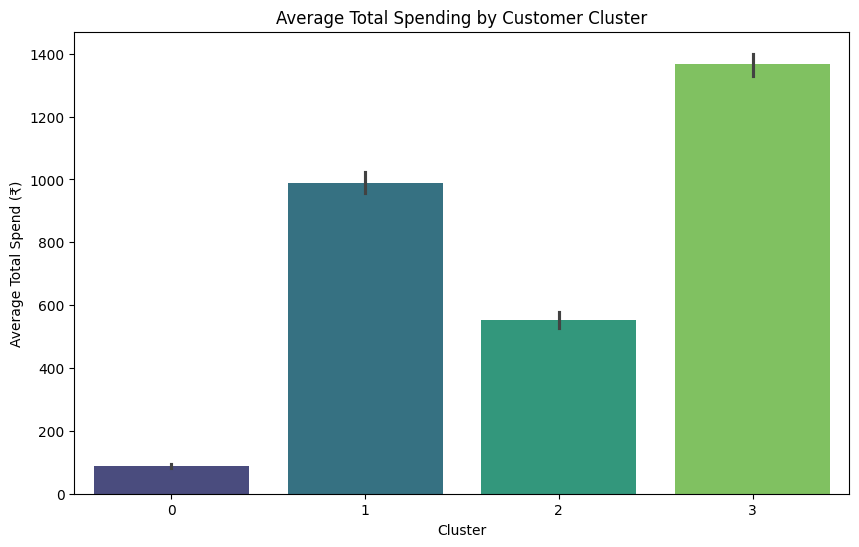

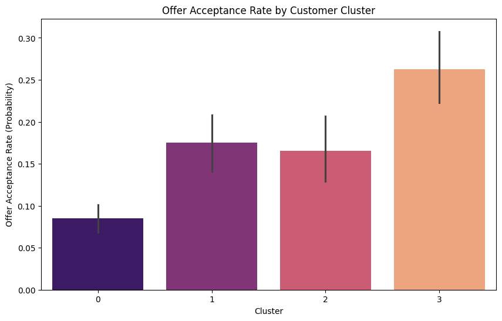

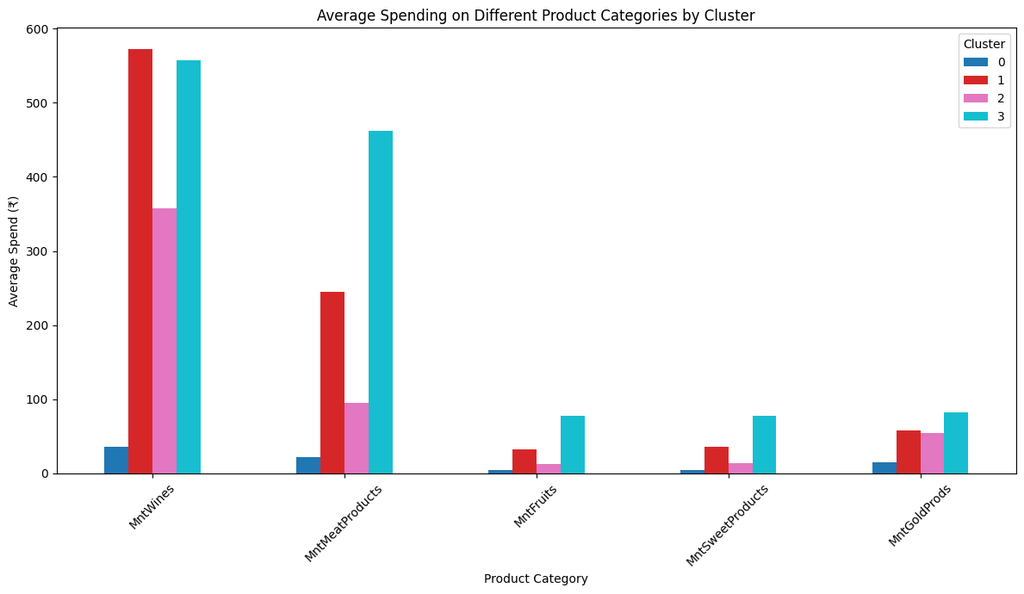

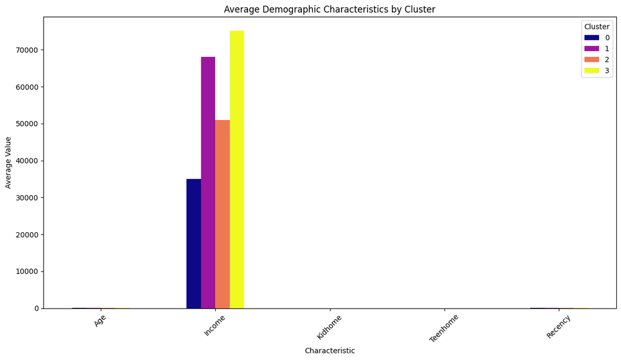

[output not shown]

```python
#Recomenadtion Based on Customer Behavior Analysis
# Visualize Spending by Cluster (Bar Plot)
plt.figure(figsize=(10, 6))
sns.barplot(x='Cluster', y='TotalSpend', data=PBA_df_winsorized, palette='viridis')
plt.title('Average Total Spending by Customer Cluster')
plt.xlabel('Cluster')
plt.ylabel('Average Total Spend (₹)')
plt.show()

# Visualize Response Rate by Cluster (Bar Plot)
plt.figure(figsize=(10, 6))
sns.barplot(x='Cluster', y='Response', data=PBA_df_winsorized, palette='magma')
plt.title('Offer Acceptance Rate by Customer Cluster')
plt.xlabel('Cluster')
plt.ylabel('Offer Acceptance Rate (Probability)')
plt.show()

# Visualize Key Spending Categories by Cluster
spending_cols = ['MntWines', 'MntMeatProducts', 'MntFruits', 'MntSweetProducts', 'MntGoldProds']
cluster_spending = PBA_df_winsorized.groupby('Cluster')[spending_cols].mean().reset_index()

plt.figure(figsize=(12, 7))
cluster_spending.set_index('Cluster').T.plot(kind='bar', figsize=(12, 7), cmap='tab10')
plt.title('Average Spending on Different Product Categories by Cluster')
plt.xlabel('Product Category')
plt.ylabel('Average Spend (₹)')
plt.xticks(rotation=45)
plt.legend(title='Cluster')
plt.tight_layout()
plt.show()


# Visualize Customer Demographics by Cluster
demographic_cols = ['Age', 'Income', 'Kidhome', 'Teenhome', 'Recency']
cluster_demographics = PBA_df_winsorized.groupby('Cluster')[demographic_cols].mean().reset_index()

plt.figure(figsize=(12, 7))
cluster_demographics.set_index('Cluster').T.plot(kind='bar', figsize=(12, 7), cmap='plasma')
plt.title('Average Demographic Characteristics by Cluster')
plt.xlabel('Characteristic')
plt.ylabel('Average Value')
plt.xticks(rotation=45)
plt.legend(title='Cluster')
plt.tight_layout()
plt.show()


# --- Actionable Recommendations based on Cluster Analysis ---

print("\n--- Actionable Recommendations ---")

# Get segment summaries (assuming the function from Task 4 is available)
segment_table = generate_segment_summary(PBA_df_winsorized)


# Iterate through the clusters and provide tailored recommendations
for index, row in segment_table.iterrows():
    cluster_id = row['Cluster']
    summary = row['Segment Summary']
    print(f"\n🔑 Recommendations for Cluster {cluster_id}:")
    print(f"Cluster Profile: {summary}") # Displaying the detailed profile from Task 4

    # Add specific recommendations based on the insights (referencing visualizations and profiles)

    if 'High-income, luxury-seeking group' in summary:
        print("  - Strategy: Target with exclusive offers on premium products (Wines, Meat, Gold). Highlight product quality and luxury.")
        print("  - Channel: Focus on personalized email campaigns and potentially direct mail for high-value customers.")
        print("  - Offer Type: Consider loyalty programs, early access to new high-end products, and VIP events.")

    elif 'Family-focused group' in summary:
        print("  - Strategy: Offer bundled deals on family-friendly products (Fruits, Sweets, basic groceries if available). Emphasize value and convenience.")
        print("  - Channel: Digital channels (web, app) for easy browsing and purchasing, social media campaigns featuring family life.")
        print("  - Offer Type: Family discounts, coupons for everyday items, 'buy one get one' on frequently purchased items.")

    elif 'Digitally active' in summary:
        print("  - Strategy: Optimize the website and mobile app experience. Ensure smooth online purchase process.")
        print("  - Channel: Digital marketing is key: SEO, SEM, targeted online ads, email marketing, social media engagement.")
        print("  - Offer Type: Web-exclusive discounts, free shipping promotions for online orders, personalized online recommendations.")

    elif 'Older low-income segment' in summary:
        print("  - Strategy: Focus on affordability and value for money. Offer deals on essential items.")
        print("  - Channel: Consider traditional channels like print media or direct mail if they are less digitally active. Ensure clear and easy-to-understand communications.")
        print("  - Offer Type: Loyalty cards with points that convert to discounts, special discounts for seniors, clear and simple promotions.")

    elif 'Balanced behavior group' in summary:
        print("  - Strategy: Continue with general marketing efforts but test different channels and offer types to see what resonates best within this diverse group.")
        print("  - Channel: Utilize a mix of online and offline channels. Monitor performance closely.")
        print("  - Offer Type: A variety of promotions – percentage discounts, fixed amount off, free gifts – tailored as data allows.")
    else:
         print("  - Strategy: General marketing efforts, monitor behavior for future refinement.")


    # General recommendation applicable to most clusters:
    print("  - General: Analyze Recency for targeted re-engagement campaigns for customers who haven't purchased recently.")
    print("  - General: Use insights on 'NumWebVisitsMonth' and purchase channels to tailor the customer journey across different platforms.")
    print("-" * 30)


# Final Summary and Overall Recommendations
print("\n--- Overall Conclusions and Strategic Recommendations ---")
print("The analysis revealed distinct customer segments with varying demographics, spending habits, and potential for offer acceptance.")
print("Tailoring marketing strategies based on these segments is crucial for optimizing campaign effectiveness.")
print("\nKey Takeaways:")
print("- High-income segments respond well to premium offers and likely have higher average transaction values.")
print("- Family segments may be price-sensitive and value convenience and deals on everyday goods.")
print("- Digitally active segments require a strong online presence and targeted digital campaigns.")
print("- Understanding the preferred purchase channels (web, store, catalog) for each segment is vital for channel allocation.")
print("- Recency analysis is important for identifying churn risk and implementing re-engagement strategies.")

print("\nStrategic Recommendations:")
print("1. Implement targeted marketing campaigns for each identified customer segment, customizing product recommendations, offer types, and communication channels.")
print("2. Allocate marketing budget based on the potential return of each segment. Invest more in segments with higher average spend or higher offer acceptance rates.")
print("3. Develop loyalty programs or tiered benefits that cater to the specific spending patterns and preferences of different clusters.")
print("4. Continuously monitor customer behavior and segment performance to refine segmentation and marketing strategies over time.")
print("5. For segments with lower engagement or response rates, consider A/B testing different approaches to identify effective strategies.")
```

```python
from IPython.display import HTML
from IPython import get_ipython

# Check if running in Colab or Jupyter
if get_ipython() is not None and 'google.colab' in str(get_ipython()):
    # Create the HTML content for the animation
    thank_you_html = """
    <style>
      @keyframes fadeInOut {
        0%, 100% { opacity: 0; }
        50% { opacity: 1; }
      }

      .animated-text {
        font-weight: bold;
        font-size: 3em; /* Adjust the size as needed */
        animation: fadeInOut 3s ease-in-out infinite; /* 3s duration, ease-in-out timing, infinite loop */
      }

      .smaller-text {
          font-size: 0.5em; /* Adjust the size as needed */
          font-weight: normal;
      }
    </style>
    <div class="animated-text">Thank you<br><span class="smaller-text">Project by Rijwan Shaikh</span></div>
    """

    # Display the HTML
    display(HTML(thank_you_html))
else:
    print("Thank you")
    print("Project by Rijwan Shaikh")
```

Thank you  
Project by Rijwan Shaikh